# Power analyses for Experiment 7

Using data from the previous experiments

Ian Hussey

09 December 2020

# Notes

- Hypothesis labels (e.g., H1c) follow the preregistration document and the analysis script.
- Power is simulated for hypotheses 1, 2, 5, 6, and 7 (i.e., the linear Bayesian models).
- This script requires the exploratory analyses script to be run first, so that the /models/ directory has the model fit objects for the empirical data present in it.
- For a cleaner html report knit this file a second time: no model fit iteration messages will be printed the second time and it will be easier to read.
- The first run (500 participants and 3000 iterations) had a run time of 9 hours on my PC with good hardware.

# Setup

```r
# dependencies
library(tidyverse)
library(simglm)
library(brms)
library(bayestestR)
library(tidybayes)
library(future)
library(furrr)
library(knitr)
library(kableExtra)

# set up parallelization
plan(multiprocess)

# create necessary folder
dir.create("models")
```

# Data and fitted models

- Calculate empirical exclusion rate, detection rate, and awareness rate from existing data.
- Load fitted meta-analyses models of existing data (fitted in the exploratory analyses script).

```r
# empirical data
data_processed <- read.csv("../data/processed/4_data_participant_level_with_hand_scoring.csv") %>%
  # include only experiments 1-6
  filter(experiment %in% c(1, 2, 3, 4, 5, 6))

empirical_exclusion_rate <- data_processed %>%
  mutate(exclude = ifelse(exclude_subject == FALSE &
                            exclude_implausible_intervention_linger == FALSE, FALSE, TRUE)) %>%
  summarize(proportion_excluded = mean(exclude)) %>%
  pull(proportion_excluded)


data_after_exclusions <- data_processed %>%
  filter(exclude_subject == FALSE &
           exclude_implausible_intervention_linger == FALSE)

empirical_deepfaked_and_awareness_rate <- data_after_exclusions %>%
  filter(!is.na(deepfake_awareness_open_recoded)) %>%
  mutate(deepfaked_and_awareness_rate = ifelse(experiment_condition == "deepfaked" &
                                                 deepfake_awareness_open_recoded == TRUE,
                                               TRUE, FALSE)) %>%
  summarize(proportion_deepfaked_and_awareness = mean(deepfaked_and_awareness_rate)) %>%
  pull(proportion_deepfaked_and_awareness)

empirical_deepfaked_and_detection_rate <- data_after_exclusions %>%
  filter(!is.na(deepfake_detection_open_recoded)) %>%
  mutate(deepfaked_and_detection_rate = ifelse(experiment_condition == "deepfaked" &
                                                 deepfake_detection_open_recoded == TRUE,
                                               TRUE, FALSE)) %>%
  summarize(proportion_deepfaked_and_detection = mean(deepfaked_and_detection_rate)) %>%
  pull(proportion_deepfaked_and_detection)

empirical_deepfaked_and_aware_and_detected_rate <- data_after_exclusions %>%
  filter(!is.na(deepfake_awareness_open_recoded) & !is.na(deepfake_detection_open_recoded)) %>%
  mutate(deepfaked_and_awareness_and_detection_rate = ifelse(experiment_condition == "deepfaked" &
                                                               deepfake_awareness_open_recoded == TRUE &
                                                               deepfake_detection_open_recoded == TRUE,
                                                             TRUE, FALSE)) %>%
  summarize(proportion_deepfaked_and_awareness_and_detection = mean(deepfaked_and_awareness_and_detection_rate)) %>%
  pull(proportion_deepfaked_and_awareness_and_detection)



# empirical fits (created by exploratory analyses script)
## H1 and H2
fit_selfreport <- read_rds("models/fit_exploratory_selfreport.rds")
fit_implicit   <- read_rds("models/fit_exploratory_implicit.rds")
fit_intentions <- read_rds("models/fit_exploratory_intentions.rds")
## H5
fit_selfreport_deepfaked_aware <- read_rds("models/fit_exploratory_selfreport_deepfaked_aware.rds")
fit_implicit_deepfaked_aware   <- read_rds("models/fit_exploratory_implicit_deepfaked_aware.rds")
fit_intentions_deepfaked_aware <- read_rds("models/fit_exploratory_intentions_deepfaked_aware.rds")
## H6
fit_selfreport_deepfaked_detected <- read_rds("models/fit_exploratory_selfreport_deepfaked_detected.rds")
fit_implicit_deepfaked_detected   <- read_rds("models/fit_exploratory_implicit_deepfaked_detected.rds")
fit_intentions_deepfaked_detected <- read_rds("models/fit_exploratory_intentions_deepfaked_detected.rds")
## H7
fit_selfreport_deepfaked_aware_detected <- read_rds("models/fit_exploratory_selfreport_deepfaked_aware_detected.rds")
fit_implicit_deepfaked_aware_detected   <- read_rds("models/fit_exploratory_implicit_deepfaked_aware_detected.rds")
fit_intentions_deepfaked_aware_detected <- read_rds("models/fit_exploratory_intentions_deepfaked_aware_detected.rds")
```

# Parameters

Note that total N_participants is intended to represent the total sample after exclusions. This number is later adjusted upwards for the empirical exclusion rate to make a data collection sample size recommendation. It is also adjusted downward for the empirical deepfake detection and deepfake concept awareness rates when simulating power for the tests that will be run in these subsets. That is, only one sample size has to be set here, necessary adjustments to this are later done in code.

```r
N_participants <- 600   # this value is changed across runs to observe its effect on the estimated power.
N_simulations  <- 1000

N_participants_deepfaked_aware          <- floor(N_participants*empirical_deepfaked_and_awareness_rate)
N_participants_deepfaked_detected       <- floor(N_participants*empirical_deepfaked_and_detection_rate)
N_participants_deepfaked_aware_detected <- floor(N_participants*empirical_deepfaked_and_aware_and_detected_rate)
```

- N participants to be simulated:
- Full sample N after exclusions that were simulated = 600
- N simulation iterations run = 1000

# Functions

Define the functions used to run the simulations.

## For H1 & H2

i.e, DV ~ 1 + source_valence * experiment_condition

- simulate_data_interaction_model(): Simulate data that mimics to the empirical data, using the fitted empirical models.
- fit_initial_interaction_model(): Fit the model to this newly simulated data, check for parameter recovery.
- simulate_data_update_fit_and_hypothesis_test_interaction_model(): Repeatedly (1) simulate new data again (calling the above function), (2) fit the model to this simulated data (by updating the fit_initial model above, in order to reuse its STAN code and therefore save a lot of run time), and (3) apply our hypothesis tests to the results of these fits.
- run_multiple_iterations_interaction_model(): Run simulate_data_update_fit_and_hypothesis_test_interaction_model() a large number of times, append and tidy its results into a tibble.
- simulate(): Check if results from a previous run of the simulation have been saved to disk and read in if so. If no, run the simulation functions above in order.

```r
simulate_data_interaction_model <- function(fitted_empirical_model, N){

  # get point estimates from fitted data
  results_empirical <- as_tibble(map_estimate(fitted_empirical_model))

  # extract these point estimates
  beta_Intercept <- results_empirical %>%
    filter(Parameter == "b_Intercept") %>%
    pull(MAP_Estimate)

  beta_source_valence <- results_empirical %>%
    filter(Parameter == "b_source_valencepositive") %>%
    pull(MAP_Estimate)

  beta_experiment_condition <- results_empirical %>%
    filter(Parameter == "b_experiment_conditiondeepfaked") %>%
    pull(MAP_Estimate)

  beta_interaction <- results_empirical %>%
    filter(Parameter == "b_source_valencepositive.experiment_conditiondeepfaked") %>%
    pull(MAP_Estimate)

  # set parameters of model to be simulated using point estimates
  simulation_arguments <-
    list(formula     = DV ~ 1 + source_valence * experiment_condition,
         reg_weights = c(beta_Intercept, beta_source_valence, beta_experiment_condition, beta_interaction),
         fixed       = list(source_valence       = list(var_type = "factor", levels = c("negative", "positive")),
                            experiment_condition = list(var_type = "factor", levels = c("genuine", "deepfaked"))),
         sample_size = N)

  # simulate data to fit_initial model
  data_simulated <- simulation_arguments %>%
    simulate_fixed(data = NULL, .) %>%
    simulate_error(simulation_arguments) %>%
    generate_response(simulation_arguments)

  return(data_simulated)

}


fit_initial_interaction_model <- function(fitted_empirical_model, N, filename){

  # NB it is faster to simulate and fit the model once, then use update() this fit, rather than generating the STAN code for the model at every iteration.

  # simulate data using fitted model
  simulated_data <- simulate_data_interaction_model(fitted_empirical_model, N = N)

  # fit the same model to the simulated data
  fit_initial <-
    brm(formula = DV ~ 1 + source_valence * experiment_condition,
        data    = simulated_data,
        prior   = prior(normal(0, 10)),
        iter    = 10000,
        warmup  = 3000,
        control = list(adapt_delta = 0.99),  # to avoid divergent transitions
        chains  = 4,
        cores   = parallel::detectCores(),
        file    = paste0("models/", filename))

  # sanity check: can we recover comparable parameters that we built the model with?
  # e.g., the fixed effect estimates should be close to the reg_weights used above.
  # get point estimates from fitted data
  results_empirical <- fitted_empirical_model %>%
    map_estimate() %>%
    as_tibble() %>%
    mutate(Parameter = case_when(
      Parameter == "b_source_valencepositive" ~ "b_source_valence",
      Parameter == "b_experiment_conditiondeepfaked" ~ "b_experiment_condition",
      Parameter == "b_source_valencepositive.experiment_conditiondeepfaked" ~ "b_interaction",
      TRUE ~ Parameter)
    ) %>%
    rename(empirical = MAP_Estimate)

  results_simulated <- fit_initial %>%
    map_estimate() %>%
    as_tibble() %>%
    mutate(Parameter = case_when(
      Parameter == "b_source_valence.experiment_condition" ~ "b_interaction",
      TRUE ~ Parameter)
    ) %>%
    rename(simulated = MAP_Estimate)

  results_comparison <- full_join(results_empirical, results_simulated, by = "Parameter")

  return(list(fitted_empirical_model = fitted_empirical_model,
              N                      = N,
              fit_initial            = fit_initial,
              results_comparison     = results_comparison))

}


simulate_data_update_fit_and_hypothesis_test_interaction_model <- function(fit_initial_model_object, seed){

  # set seed
  set.seed(seed)

  # simulate data using fitted model
  simulated_data <- simulate_data_interaction_model(fitted_empirical_model = fit_initial_model_object$fitted_empirical_model,
                                                    N = fit_initial_model_object$N)

  # find a new (updated) fit using the newly simulated data
  fit_updated <- update(fit_initial_model_object$fit_initial, newdata = simulated_data)

  # manipulate posterior distributions
  draws_fit_updated <-
    bind_cols(select(spread_draws(fit_updated, b_Intercept),            b_Intercept),
              select(spread_draws(fit_updated, b_source_valence),       b_source_valence),
              select(spread_draws(fit_updated, b_experiment_condition), b_experiment_condition),
              select(spread_draws(fit_updated, `b_source_valence:experiment_condition`),
                     b_interaction = `b_source_valence:experiment_condition`)) %>%
    mutate(effect_genuine   = b_source_valence,
           effect_deepfaked = b_source_valence + b_interaction)

  # parameterize posteriors
  estimates_fit_updated <-
    map_estimate(draws_fit_updated) %>%
    # 95% CIs
    full_join(bayestestR::hdi(draws_fit_updated, ci = .95) %>%
                as_tibble() %>%
                rename(CI_95_lower = CI_low),
              by = "Parameter") %>%
    # 90% CIs (for non-inferiority test)
    full_join(bayestestR::hdi(draws_fit_updated, ci = .90) %>%
                as_tibble() %>%
                rename(CI_90_lower = CI_low),
              by = "Parameter") %>%
    select(Parameter, MAP_Estimate, CI_95_lower, CI_90_lower)

  # lower CI estimates hypothesis tests
  effect_genuine_MAP <- estimates_fit_updated %>%
    filter(Parameter == "effect_genuine") %>%
    pull(MAP_Estimate)

  effect_deepfaked_MAP <- estimates_fit_updated %>%
    filter(Parameter == "effect_deepfaked") %>%
    pull(MAP_Estimate)

  # lower CI estimates hypothesis tests
  effect_genuine_95_CI_lower <- estimates_fit_updated %>%
    filter(Parameter == "effect_genuine") %>%
    pull(CI_95_lower)

  effect_deepfaked_95_CI_lower <- estimates_fit_updated %>%
    filter(Parameter == "effect_deepfaked") %>%
    pull(CI_95_lower)

  effect_deepfaked_90_CI_lower <- estimates_fit_updated %>%
    filter(Parameter == "effect_deepfaked") %>%
    pull(CI_90_lower)

  ## non-zero effect in genuine condition
  H1_genuine <- ifelse(effect_genuine_95_CI_lower > 0, 1, 0)
  ## non-zero effect in deepfake condition
  H1_deepfaked <- ifelse(effect_deepfaked_95_CI_lower > 0, 1, 0)
  ## non-inferiority of deepfakes compared to genuine
  H2_noninferiority <- ifelse(effect_genuine_95_CI_lower < effect_deepfaked_90_CI_lower, 1, 0)

  # binary hypothesis tests
  results_simulation <- tibble(effect_genuine_MAP           = effect_genuine_MAP,
                               effect_genuine_95_CI_lower   = effect_genuine_95_CI_lower,
                               effect_deepfaked_MAP         = effect_deepfaked_MAP,
                               effect_deepfaked_95_CI_lower = effect_deepfaked_95_CI_lower,
                               effect_deepfaked_90_CI_lower = effect_deepfaked_90_CI_lower,
                               H1_genuine                   = H1_genuine,
                               H1_deepfaked                 = H1_deepfaked,
                               H2_noninferiority            = H2_noninferiority)

  return(results_simulation)

}


run_multiple_iterations_interaction_model <- function(fit_initial_model_object, n_sim){

  results <-
    tibble(seed = 1:n_sim) %>%
    mutate(tidy = future_map(seed, simulate_data_update_fit_and_hypothesis_test_interaction_model,
                             .options = furrr_options(seed = TRUE),
                             .progress = TRUE,
                             fit_initial_model_object = fit_initial_model_object)) %>%
    unnest(tidy)

  return(results)

}


simulate_interaction_model <- function(results_file, empirical_model_fit, N_simulated_participants, iterations, initial_fit_filename){
  if(file.exists(paste0("models/", results_file, ".csv"))){
    simulation_iterations <- read.csv(paste0("models/", results_file, ".csv"))
  } else {
    # run simulations
    simulation_iterations <- empirical_model_fit %>%
      fit_initial_interaction_model(fitted_empirical_model = .,
                                    filename = initial_fit_filename,
                                    N = N_simulated_participants) %>%
      run_multiple_iterations_interaction_model(fit_initial_model_object = .,
                                                n_sim = iterations)
    # write to disk
    simulation_iterations %>%
      write_csv(paste0("models/", results_file, ".csv"))
  }
  return(simulation_iterations)
}
```

## For H5, H6, & H7

i.e, DV ~ 1 + source_valence run on a subset.

Functions serve same purpose as those named for H1 and H2.

NB these functions are copies of the above ones with changes to the model or the way priors are manipulated or tested to remove the experiment_condition variable.

```r
simulate_data_simple_model <- function(fitted_empirical_model, N){

  # get point estimates from fitted data
  results_empirical <- as_tibble(map_estimate(fitted_empirical_model))

  # extract these point estimates
  beta_Intercept <- results_empirical %>%
    filter(Parameter == "b_Intercept") %>%
    pull(MAP_Estimate)

  beta_source_valence <- results_empirical %>%
    filter(Parameter == "b_source_valencepositive") %>%
    pull(MAP_Estimate)

  # set parameters of model to be simulated using point estimates
  simulation_arguments <-
    list(formula     = DV ~ 1 + source_valence,
         reg_weights = c(beta_Intercept, beta_source_valence),
         fixed       = list(source_valence = list(var_type = "factor", levels = c("negative", "positive"))),
         sample_size = N)

  # simulate data to fit_initial model
  data_simulated <- simulation_arguments %>%
    simulate_fixed(data = NULL, .) %>%
    simulate_error(simulation_arguments) %>%
    generate_response(simulation_arguments)

  return(data_simulated)

}


fit_initial_simple_model <- function(fitted_empirical_model, N, filename){

  # NB it is faster to simulate and fit the model once, then use update() this fit, rather than generating the STAN code for the model at every iteration.

  # simulate data using fitted model
  simulated_data <- simulate_data_simple_model(fitted_empirical_model, N = N)

  # fit the same model to the simulated data
  fit_initial <-
    brm(formula = DV ~ 1 + source_valence,
        data    = simulated_data,
        prior   = prior(normal(0, 10)),
        iter    = 10000,
        warmup  = 3000,
        control = list(adapt_delta = 0.99),  # to avoid divergent transitions
        chains  = 4,
        cores   = parallel::detectCores(),
        file    = paste0("models/", filename))

  # sanity check: can we recover comparable parameters that we built the model with?
  # e.g., the fixed effect estimates should be close to the reg_weights used above.
  # get point estimates from fitted data
  results_empirical <- fitted_empirical_model %>%
    map_estimate() %>%
    as_tibble() %>%
    mutate(Parameter = case_when(
      Parameter == "b_source_valencepositive" ~ "b_source_valence",
      TRUE ~ Parameter)
    ) %>%
    rename(empirical = MAP_Estimate)

  results_simulated <- fit_initial %>%
    map_estimate() %>%
    as_tibble() %>%
    rename(simulated = MAP_Estimate)

  results_comparison <- full_join(results_empirical, results_simulated, by = "Parameter")

  return(list(fitted_empirical_model = fitted_empirical_model,
              N                      = N,
              fit_initial            = fit_initial,
              results_comparison     = results_comparison))

}


simulate_data_update_fit_and_hypothesis_test_simple_model <- function(fit_initial_model_object, seed){

  # set seed
  set.seed(seed)

  # simulate data using fitted model
  simulated_data <- simulate_data_simple_model(fitted_empirical_model = fit_initial_model_object$fitted_empirical_model,
                                               N = fit_initial_model_object$N)

  # find a new (updated) fit using the newly simulated data
  fit_updated <- update(fit_initial_model_object$fit_initial, newdata = simulated_data)

  # manipulate posterior distributions
  draws_fit_updated <-
    bind_cols(select(spread_draws(fit_updated, b_Intercept),            b_Intercept),
              select(spread_draws(fit_updated, b_source_valence),       b_source_valence)) %>%
    mutate(effect_deepfaked = b_source_valence)

  # parameterize posteriors
  estimates_fit_updated <-
    map_estimate(draws_fit_updated) %>%
    # 95% CIs
    full_join(bayestestR::hdi(draws_fit_updated, ci = .95) %>%
                as_tibble() %>%
                rename(CI_95_lower = CI_low),
              by = "Parameter") %>%
    select(Parameter, MAP_Estimate, CI_95_lower)

  # lower CI estimates hypothesis tests
  effect_deepfaked_MAP <- estimates_fit_updated %>%
    filter(Parameter == "effect_deepfaked") %>%
    pull(MAP_Estimate)

  # lower CI estimates hypothesis tests
  effect_deepfaked_95_CI_lower <- estimates_fit_updated %>%
    filter(Parameter == "effect_deepfaked") %>%
    pull(CI_95_lower)

  ## non-zero effect in deepfake condition
  H567_deepfaked <- ifelse(effect_deepfaked_95_CI_lower > 0, 1, 0)

  # binary hypothesis tests
  results_simulation <- tibble(effect_deepfaked_MAP         = effect_deepfaked_MAP,
                               effect_deepfaked_95_CI_lower = effect_deepfaked_95_CI_lower,
                               H567_deepfaked               = H567_deepfaked)

  return(results_simulation)

}


run_multiple_iterations_simple_model <- function(fit_initial_model_object, n_sim){

  results <-
    tibble(seed = 1:n_sim) %>%
    mutate(tidy = future_map(seed, simulate_data_update_fit_and_hypothesis_test_simple_model,
                             .options = furrr_options(seed = TRUE),
                             .progress = TRUE,
                             fit_initial_model_object = fit_initial_model_object)) %>%
    unnest(tidy)

  return(results)

}


simulate_simple_model <- function(results_file, empirical_model_fit, N_simulated_participants, iterations, initial_fit_filename){
  if(file.exists(paste0("models/", results_file, ".csv"))){
    simulation_iterations <- read.csv(paste0("models/", results_file, ".csv"))
  } else {
    # run simulations
    simulation_iterations <- empirical_model_fit %>%
      fit_initial_simple_model(fitted_empirical_model = .,
                               filename = initial_fit_filename,
                               N = N_simulated_participants) %>%
      run_multiple_iterations_simple_model(fit_initial_model_object = .,
                                           n_sim = iterations)
    # write to disk
    simulation_iterations %>%
      write_csv(paste0("models/", results_file, ".csv"))
  }
  return(simulation_iterations)
}
```

# Run simulations

For each DV and their hypothesis.

## For H1 & H2

```r
# initial models
parameter_recovery_self_report <-
  fit_initial_interaction_model(fitted_empirical_model = fit_selfreport,
                                filename = "fit_simulation_initial_selfreport",
                                N = N_participants)

parameter_recovery_implicit <-
  fit_initial_interaction_model(fitted_empirical_model = fit_implicit,
                                filename = "fit_simulation_initial_implicit",
                                N = N_participants)

parameter_recovery_intentions <-
  fit_initial_interaction_model(fitted_empirical_model = fit_intentions,
                                filename = "fit_simulation_initial_intentions",
                                N = N_participants)

# simulations
simulation_iterations_self_report <-
  simulate_interaction_model(results_file             = "simulation_iterations_self_report",
                             initial_fit_filename     = "fit_simulation_initial_selfreport",
                             empirical_model_fit      = fit_selfreport,
                             N_simulated_participants = N_participants,
                             iterations               = N_simulations)

simulation_iterations_implicit <-
  simulate_interaction_model(results_file             = "simulation_iterations_implicit",
                             initial_fit_filename     = "fit_simulation_initial_implicit",
                             empirical_model_fit      = fit_implicit,
                             N_simulated_participants = N_participants,
                             iterations               = N_simulations)

simulation_iterations_intentions <-
  simulate_interaction_model(results_file             = "simulation_iterations_intentions",
                             initial_fit_filename     = "fit_simulation_initial_intentions",
                             empirical_model_fit      = fit_intentions,
                             N_simulated_participants = N_participants,
                             iterations               = N_simulations)
```

## For H5, H6, & H7

```r
# initial models
## H5
parameter_recovery_self_report_deepfaked_aware <-
  fit_initial_simple_model(fitted_empirical_model = fit_selfreport_deepfaked_aware,
                           filename = "fit_simulation_initial_selfreport_deepfaked_aware",
                           N = N_participants_deepfaked_aware)

parameter_recovery_implicit_deepfaked_aware <-
  fit_initial_simple_model(fitted_empirical_model = fit_implicit_deepfaked_aware,
                           filename = "fit_simulation_initial_implicit_deepfaked_aware",
                           N = N_participants_deepfaked_aware)

parameter_recovery_intentions_deepfaked_aware <-
  fit_initial_simple_model(fitted_empirical_model = fit_intentions_deepfaked_aware,
                           filename = "fit_simulation_initial_intentions_deepfaked_aware",
                           N = N_participants_deepfaked_aware)

## H6
parameter_recovery_self_report_deepfaked_detected <-
  fit_initial_simple_model(fitted_empirical_model = fit_selfreport_deepfaked_detected,
                           filename = "fit_simulation_initial_selfreport_deepfaked_detected",
                           N = N_participants_deepfaked_detected)

parameter_recovery_implicit_deepfaked_detected <-
  fit_initial_simple_model(fitted_empirical_model = fit_implicit_deepfaked_detected,
                           filename = "fit_simulation_initial_implicit_deepfaked_detected",
                           N = N_participants_deepfaked_detected)

parameter_recovery_intentions_deepfaked_detected <-
  fit_initial_simple_model(fitted_empirical_model = fit_intentions_deepfaked_detected,
                           filename = "fit_simulation_initial_intentions_deepfaked_detected",
                           N = N_participants_deepfaked_detected)

## H7
parameter_recovery_self_report_deepfaked_aware_detected <-
  fit_initial_simple_model(fitted_empirical_model = fit_selfreport_deepfaked_aware_detected,
                           filename = "fit_simulation_initial_selfreport_deepfaked_aware_detected",
                           N = N_participants_deepfaked_aware_detected)

parameter_recovery_implicit_deepfaked_aware_detected <-
  fit_initial_simple_model(fitted_empirical_model = fit_implicit_deepfaked_aware_detected,
                           filename = "fit_simulation_initial_implicit_deepfaked_aware_detected",
                           N = N_participants_deepfaked_aware_detected)

parameter_recovery_intentions_deepfaked_aware_detected <-
  fit_initial_simple_model(fitted_empirical_model = fit_intentions_deepfaked_aware_detected,
                           filename = "fit_simulation_initial_intentions_deepfaked_aware_detected",
                           N = N_participants_deepfaked_aware_detected)

# run simulations
# H5
simulation_iterations_self_report_deepfaked_aware <-
  simulate_simple_model(results_file             = "simulation_iterations_self_report_deepfaked_aware",
                        initial_fit_filename     = "fit_simulation_initial_selfreport_deepfaked_aware",
                        empirical_model_fit      = fit_selfreport_deepfaked_aware,
                        N_simulated_participants = N_participants_deepfaked_aware,
                        iterations               = N_simulations)

simulation_iterations_implicit_deepfaked_aware <-
  simulate_simple_model(results_file             = "simulation_iterations_implicit_deepfaked_aware",
                        initial_fit_filename     = "fit_simulation_initial_implicit_deepfaked_aware",
                        empirical_model_fit      = fit_implicit_deepfaked_aware,
                        N_simulated_participants = N_participants_deepfaked_aware,
                        iterations               = N_simulations)

simulation_iterations_intentions_deepfaked_aware <-
  simulate_simple_model(results_file             = "simulation_iterations_intentions_deepfaked_aware",
                        initial_fit_filename     = "fit_simulation_initial_intentions_deepfaked_aware",
                        empirical_model_fit      = fit_intentions_deepfaked_aware,
                        N_simulated_participants = N_participants_deepfaked_aware,
                        iterations               = N_simulations)

# H6
simulation_iterations_self_report_deepfaked_detected <-
  simulate_simple_model(results_file             = "simulation_iterations_self_report_deepfaked_detected",
                        initial_fit_filename     = "fit_simulation_initial_selfreport_deepfaked_detected",
                        empirical_model_fit      = fit_selfreport_deepfaked_detected,
                        N_simulated_participants = N_participants_deepfaked_detected,
                        iterations               = N_simulations)

simulation_iterations_implicit_deepfaked_detected <-
  simulate_simple_model(results_file             = "simulation_iterations_implicit_deepfaked_detected",
                        initial_fit_filename     = "fit_simulation_initial_implicit_deepfaked_detected",
                        empirical_model_fit      = fit_implicit_deepfaked_detected,
                        N_simulated_participants = N_participants_deepfaked_detected,
                        iterations               = N_simulations)

simulation_iterations_intentions_deepfaked_detected <-
  simulate_simple_model(results_file             = "simulation_iterations_intentions_deepfaked_detected",
                        initial_fit_filename     = "fit_simulation_initial_intentions_deepfaked_detected",
                        empirical_model_fit      = fit_intentions_deepfaked_detected,
                        N_simulated_participants = N_participants_deepfaked_detected,
                        iterations               = N_simulations)

# H7
simulation_iterations_self_report_deepfaked_aware_detected <-
  simulate_simple_model(results_file             = "simulation_iterations_self_report_deepfaked_aware_detected",
                        initial_fit_filename     = "fit_simulation_initial_selfreport_deepfaked_aware_detected",
                        empirical_model_fit      = fit_selfreport_deepfaked_aware_detected,
                        N_simulated_participants = N_participants_deepfaked_aware_detected,
                        iterations               = N_simulations)

simulation_iterations_implicit_deepfaked_aware_detected <-
  simulate_simple_model(results_file             = "simulation_iterations_implicit_deepfaked_aware_detected",
                        initial_fit_filename     = "fit_simulation_initial_implicit_deepfaked_aware_detected",
                        empirical_model_fit      = fit_implicit_deepfaked_aware_detected,
                        N_simulated_participants = N_participants_deepfaked_aware_detected,
                        iterations               = N_simulations)

simulation_iterations_intentions_deepfaked_aware_detected <-
  simulate_simple_model(results_file             = "simulation_iterations_intentions_deepfaked_aware_detected",
                        initial_fit_filename     = "fit_simulation_initial_intentions_deepfaked_aware_detected",
                        empirical_model_fit      = fit_intentions_deepfaked_aware_detected,
                        N_simulated_participants = N_participants_deepfaked_aware_detected,
                        iterations               = N_simulations)
```

# Results

## Sample sizes

- N (after exclusions) for H1 & H2 = 600
- Likely N needing to be recruited to obtain the above = 772
- Likely N for H5 (shown Deepfaked content and reported prior awareness of Deepfaking) = 166
- Likely N for H6 (shown Deepfaked content and detected the Deepfake) = 103
- Likely N for H7 (shown Deepfaked content, reported prior awareness of Deepfaking, and detected the Deepfake) = 46
- N simulation iterations run = 1000

## Power

Based on the meta-analyses of our experiments so far, and taking the empirical exclusion rate into account (i.e., 22.2%), a sample size of $N \geq$ 772 would provide the following degree of statistical power to test each hypothesis.

### For H1 & H2

```r
# combine
simuations_iterations <-
  bind_rows(simulation_iterations_self_report %>% mutate(DV = "Self report"),
            simulation_iterations_implicit    %>% mutate(DV = "Implicit"),
            simulation_iterations_intentions  %>% mutate(DV = "Intentions")) %>%
  mutate(DV = fct_relevel(DV, "Self report", "Implicit", "Intentions"))

# table
simuations_iterations %>%
  select(DV, H1_genuine, H1_deepfaked, H2_noninferiority) %>%
  pivot_longer(cols = c(H1_genuine, H1_deepfaked, H2_noninferiority),
               names_to = "detail",
               values_to = "detected") %>%
  group_by(DV, detail) %>%
  summarize(power = mean(detected), .groups = "drop") %>%
  mutate(hypothesis = paste(DV, detail, sep = "_"),
         hypothesis = case_when(hypothesis == "Self report_H1_genuine" ~ "H1a",
                                hypothesis == "Self report_H1_deepfaked" ~ "H1b",
                                hypothesis == "Self report_H2_noninferiority" ~ "H2a",
                                hypothesis == "Implicit_H1_genuine" ~ "H1c",
                                hypothesis == "Implicit_H1_deepfaked" ~ "H1d",
                                hypothesis == "Implicit_H2_noninferiority" ~ "H2b",
                                hypothesis == "Intentions_H1_genuine" ~ "H1e",
                                hypothesis == "Intentions_H1_deepfaked" ~ "H1f",
                                hypothesis == "Intentions_H2_noninferiority" ~ "H2c")) %>%
  select(hypothesis, DV, detail, power) %>%
  arrange(hypothesis) %>%
  kable() %>%
  kable_styling(bootstrap_options = c("striped", "hover", "condensed"), full_width = FALSE)
```

| hypothesis | DV | detail | power |
| --- | --- | --- | --- |
| H1a | Self report | H1_genuine | 1.000 |
| H1b | Self report | H1_deepfaked | 1.000 |
| H1c | Implicit | H1_genuine | 1.000 |
| H1d | Implicit | H1_deepfaked | 1.000 |
| H1e | Intentions | H1_genuine | 1.000 |
| H1f | Intentions | H1_deepfaked | 1.000 |
| H2a | Self report | H2_noninferiority | 0.628 |
| H2b | Implicit | H2_noninferiority | 0.619 |
| H2c | Intentions | H2_noninferiority | 1.000 |

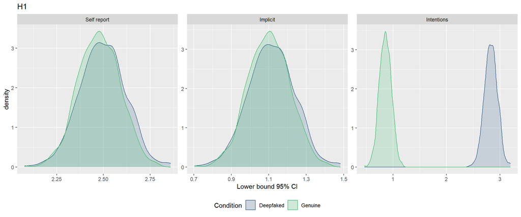

```r
# H1 plot
simuations_iterations %>%
  select(DV,
         Genuine   = effect_genuine_95_CI_lower,
         Deepfaked = effect_deepfaked_95_CI_lower) %>%
  pivot_longer(cols      = c(Genuine, Deepfaked),
               names_to  = "Condition",
               values_to = "value") %>%
  ggplot(aes(value, color = Condition, fill = Condition)) +
  geom_density(alpha = 0.2) +
  scale_color_viridis_d(begin = 0.3, end = 0.7) +
  scale_fill_viridis_d(begin = 0.3, end = 0.7) +
  xlab("Lower bound 95% CI") +
  facet_wrap(~ DV, scales = "free") +
  theme(legend.position = "bottom") +
  ggtitle("H1")
```

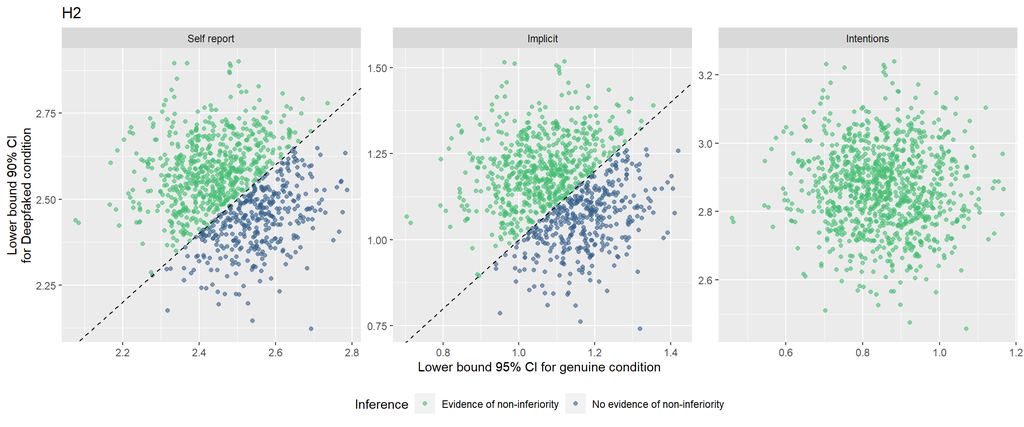

```r
# H2 plot
simuations_iterations %>%
  select(DV,
         Genuine   = effect_genuine_95_CI_lower,
         Deepfaked = effect_deepfaked_90_CI_lower) %>%
  mutate(Inference = ifelse(Genuine < Deepfaked, "Evidence of non-inferiority", "No evidence of non-inferiority")) %>%
  ggplot(aes(Genuine, Deepfaked, color = Inference)) +
  geom_point(alpha = 0.6) +
  geom_abline(slope = 1, linetype = "dashed") +
  scale_color_viridis_d(begin = 0.3, end = 0.7, direction = -1) +
  xlab("Lower bound 95% CI for genuine condition") +
  ylab("Lower bound 90% CI\nfor Deepfaked condition") +
  facet_wrap(~ DV, scales = "free") +
  theme(legend.position = "bottom") +
  ggtitle("H2")
```

### For H5, H6, & H7

```r
# combine
simuations_iterations_deepfaked_detected <-
  bind_rows(simulation_iterations_self_report_deepfaked_aware          %>% mutate(DV = "Self report", related_hypothesis = "H5"),
            simulation_iterations_implicit_deepfaked_aware             %>% mutate(DV = "Implicit",    related_hypothesis = "H5"),
            simulation_iterations_intentions_deepfaked_aware           %>% mutate(DV = "Intentions",  related_hypothesis = "H5"),
            simulation_iterations_self_report_deepfaked_detected       %>% mutate(DV = "Self report", related_hypothesis = "H6"),
            simulation_iterations_implicit_deepfaked_detected          %>% mutate(DV = "Implicit",    related_hypothesis = "H6"),
            simulation_iterations_intentions_deepfaked_detected        %>% mutate(DV = "Intentions",  related_hypothesis = "H6"),
            simulation_iterations_self_report_deepfaked_aware_detected %>% mutate(DV = "Self report", related_hypothesis = "H7"),
            simulation_iterations_implicit_deepfaked_aware_detected    %>% mutate(DV = "Implicit",    related_hypothesis = "H7"),
            simulation_iterations_intentions_deepfaked_aware_detected  %>% mutate(DV = "Intentions",  related_hypothesis = "H7")) %>%
  mutate(DV = fct_relevel(DV, "Self report", "Implicit", "Intentions"))

# table
simuations_iterations_deepfaked_detected %>%
  select(related_hypothesis, DV, detected = H567_deepfaked) %>%
  group_by(related_hypothesis, DV) %>%
  summarize(power = mean(detected), .groups = "drop") %>%
  mutate(hypothesis = paste(DV, related_hypothesis, sep = "_")) %>%
  select(hypothesis, DV, power) %>%
  arrange(hypothesis) %>%
  kable() %>%
  kable_styling(bootstrap_options = c("striped", "hover", "condensed"), full_width = FALSE)
```

| hypothesis | DV | power |
| --- | --- | --- |
| Implicit_H5 | Implicit | 1.000 |
| Implicit_H6 | Implicit | 1.000 |
| Implicit_H7 | Implicit | 0.982 |
| Intentions_H5 | Intentions | 1.000 |
| Intentions_H6 | Intentions | 1.000 |
| Intentions_H7 | Intentions | 1.000 |
| Self report_H5 | Self report | 1.000 |
| Self report_H6 | Self report | 1.000 |
| Self report_H7 | Self report | 1.000 |

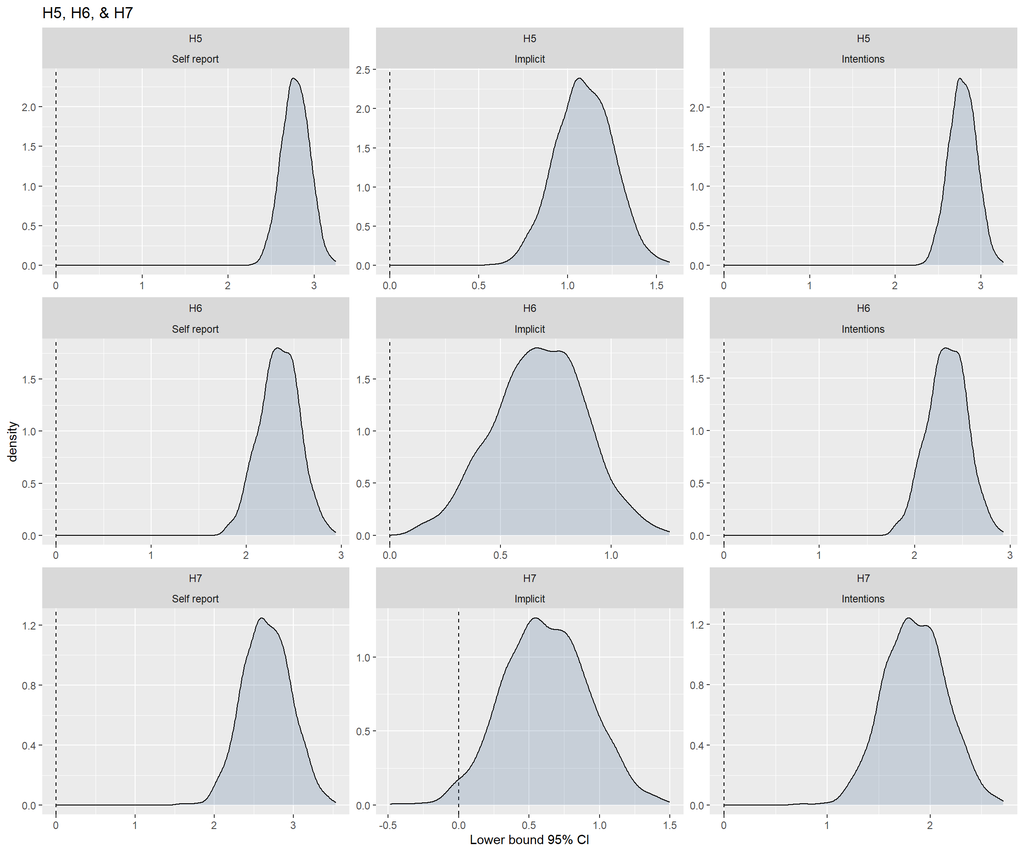

```r
simuations_iterations_deepfaked_detected %>%
  select(related_hypothesis, DV, Deepfaked = effect_deepfaked_95_CI_lower) %>%
  ggplot(aes(Deepfaked, fill = "grey")) +
  geom_vline(xintercept = 0, linetype = "dashed") +
  geom_density(alpha = 0.2) +
  scale_color_viridis_d(begin = 0.3, end = 0.7) +
  scale_fill_viridis_d(begin = 0.3, end = 0.7) +
  xlab("Lower bound 95% CI") +
  facet_wrap(~ related_hypothesis + DV, scales = "free") +
  theme(legend.position = "bottom") +
  ggtitle("H5, H6, & H7") +
  theme(legend.position = "none")
```

# Resources

I used the [{simglm} package’s vignette](https://cran.r-project.org/web/packages/simglm/vignettes/tidy_simulation.html) and [Solomon Kurz’s blog post on Bayesian power analysis using {tidyverse} and {brms}](https://solomonkurz.netlify.app/post/bayesian-power-analysis-part-i/) to create this simulation: many thanks to both.